# ✳ Neural Network

## ✅ Perceptron to Neural Network

### ▶ Concept

- 신경망은 가중치 매개변수의 적절한 값을 자동으로 학습

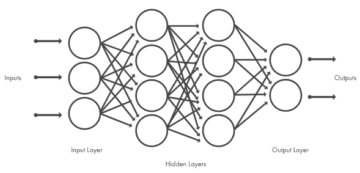

### ▶ Perceptron

$ y = \begin{cases}0 \;if\;b + w_1x_1 + w_2x_2 <= 0\\ 1 \;if\; b + w_1x_1 + w_2x_2 > 0\end{cases} $

- $b(bias)$ : 뉴런이 얼마나 쉽게 활성화되는가
- $w_1, w_2$ : 각 신호의 영향력 제어

#### 🔽 더 간결한 형태의 식

$ y = h(b + w_1x_1 + w_2x_2) $

$ h(x) = \begin{cases}0 \;if\;x <= 0\\ 1 \;if\; x > 0\end{cases} $

### ▶ Activation function

- 활성화 함수(Activation function) : 입력신호의 총합을 출력신호로 변환하는 함수

#### 🔽 두 단계로 나눈 식

- <단계 1> $a = b + w_1x_1 + w_2x+2$
- <단계 2> $y = h(a)$ ➡ 가중치가 곱해진 입력신호의 총합을 먼저 구하고(1단계), 총합을 활성화 함수에 입력하여 결과값 도출(2단계) : 가중치 신호가 조합한 결과 a 노드를 활성화 함수 h()에 통과하여 y라는 노드로 변환된다

## ✅ Activaton function

### ▶ Sigmoid function

$h(x) = \frac{1}{1 + exp(-x)}$

- $exp(-x)$ 는 $e^{-x}$ 를 의미

### ▶ Step function

```python
import numpy as np
x = np.array([-1.0, 1.0, 2.0])
print(x)
y = x > 0
y = y.astype(np.int64)
print(y)
```

```
[-1.  1.  2.]
[0 1 1]
```

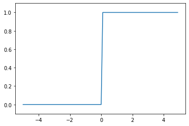

```python
import numpy as np
import matplotlib.pylab as plt
def step_function(x):
    return np.array(x > 0, dtype=np.int64)

x = np.arange(-5.0, 5.0, 0.1)
y = step_function(x)
plt.plot(x, y)
plt.ylim(-0.1, 1.1)
plt.show()
```

### ▶ Sigmoid vs Step

```python
# sigmoid function
def sigmoid(x):
    return 1 / (1 + np.exp(-x))

x = np.array([-1.0, 1.0, 2.0])
print(sigmoid(x))
```

```
[0.26894142 0.73105858 0.88079708]
```

- numpy 의 broadcast 로 기능 : numpy 배열과 scala 연산을 배열의 원소 각각과 scala값의 연산으로 바꾸어 수행하는 것

🔽 Sigmoid function graph

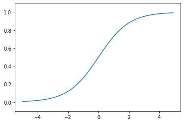

```python
x = np.arange(-5.0, 5.0, 0.1)
y = sigmoid(x)
plt.plot(x, y)
plt.ylim(-0.1, 1.1)
plt.show()
```

🔽 step function과 sigmoid function의 차이

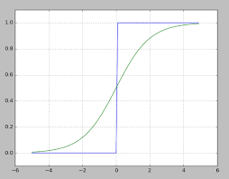

🔽 step function과 sigmoid function의 공통점

- 그래프를 큰 관점에서 바라보면 두 함수 모두 input값이 작을 때는 0에 가까워지고, input이 클 때는 1에 가까워짐
- input값과 관련없이 언제나 0~1 사이의 output을 도출

### ▶ 비선형 함수 (Non-linear function)

- 신경망에서는 활성화함수로 비선형 함수만을 사용해야 함
  - -> 선형 함수를 사용하면 신경망을 깊게 하는 의미가 없기 때문
  - 선형 함수는 층을 아무리 깊에 해도 은닉층이 없는 네트워크로 표현할 수 있기 때문에 메리트가 없음
  - $h(x) = cx$를 활성화 함수로 한 3층 네트워크는 $y(x) = h(h(h(x)))$로 표현 가능
    - 그러나 이 식은 사실상 $y(x) = ax$와 같다. 왜냐하면 $y(x) = c * c* c* x = c^3$ 이기 때문
    - 그래서 선형 함수를 활성화 함수로 사용하는 것은 무의미하다

### ▶ ReLU(Rectified Linear Unit) function

- ReLU함수는 0이 넘으면 그 입력을 그대로 출력하고, 0 이하이면 0을 출력
- $ h(x) = \begin{cases}x \;if\;x > 0\\ 0 \;if\; x <= 0\end{cases} $

```python
def relu(x):
    return np.maximum(0, x)
```